# Multiple Mediation Analysis with `mediateR`

James P. Long, PhD. and Licai Huang

```r
library(graph)
library(kableExtra)
library(mediateR)
set.seed(280920181)
```

# 1 Data Structure

The code contains functions to simulate data for mediation analysis.

```r
params <- mediateR:::QuickSim(5,3,2,"gaussian")
dat <- SimulateData(params)
dat
```

```
## $y
## [1]  6.689322 10.458142 -5.129216  3.500655  6.131457
##
## $mm
##               m1        m2
## [1,]  0.13625178  1.318617
## [2,]  1.00977372  1.762004
## [3,] -0.04329309 -1.954473
## [4,] -0.56942592  1.178782
## [5,] -0.16066622  0.643474
##
## $xx
##      x1 x2 x3
## [1,]  1  1  1
## [2,]  1  1  0
## [3,]  0  0  0
## [4,]  0  0  1
## [5,]  1  1  1
##
## $co
##
## [1,]
## [2,]
## [3,]
## [4,]
## [5,]
##
## $path
##    m1 m2
## x1  1  0
## x2  1  1
## x3  0  1
##
## $family
## [1] "gaussian"
```

The `dat` list with named elements (y, mm, xx, co, path, family) is used as an argument for functions which estimate the direct and indirect effects.

- `dat$y` is the response,
- `dat$mm` is the vector of the mediators,
- `dat$xx` is the vector of the exposures,
- `dat$co` is the vector of the covariates, and
- `dat$family` denotes the type of response.
- `dat$path` is p x q matrix of 0s and 1s denoting paths to be fit. path[i,j]=0 indicates a priori knowledge of no path xx[i] and mm[j].

One can manually create a list with these elements (such as when fitting models to new data) or rely on the simulation function `SimulateData` to create the structure. The argument to `SimulateData` has parameters controlling the sample size, coefficient estimates, number of mediators, etc.

# 2 Mediation Analysis

The goal is to assess the causal impact of `dat$xx` on `dat$y` and quantify how much of this effect passes through `dat$mm`, adjusting for covariates `dat$co`.

## 2.1 Linear

We simulate `n` observations from the “True Graph” using independent, binary SNPs drawn from Bernoulli(1/2) and path coefficients given below.

```r
n <- 500
sim_params <- mediateR:::QuickSim(n,3,2,"gaussian")
dat <- SimulateData(sim_params)
```

### 2.1.1 Model fitting

`ComputePath` is used to fit the mediation analysis framework for various response, where `dat` are the datalist with the format mentioned above, `mmn=F` assuming independent mediators and `reg=T` is used for high-dimensional mediators (default is false).

If one makes the assumption of conditionally independent mediators given $\mathbf{x}$ and $\mathbf{c}$, i.e., $m_j \perp \!\!\! \perp m_k | \mathbf{x},\mathbf{c}$, for all $j,k$, then $\mathbf{\Sigma}_\epsilon$ is diagonal and can be estimated using the error variances from separate univariate regressions, $m_j | (x,c)$ for all $j$. This estimate will be more efficient, but carries more assumptions.

```r
fit <- ComputePath(dat, mmn = T, reg = F)
eff_est <- ComputeEffectsLinear(fit)
```

```r
eff <- ComputeEffectsLinear(sim_params)
eff_comb <- matrix(0,nrow(eff),ncol=2*ncol(eff))
for(ii in 1:ncol(eff)){
  eff_comb[,2*ii-1] <- eff_est[,ii]
  eff_comb[,2*ii] <- eff[,ii]
}
for(ii in (ncol(dat$xx)+1):(ncol(dat$xx)+ncol(dat$mm))){
  eff_comb[ii,3:ncol(eff_comb)] <- NA
}
colnames(eff_comb) <- rep(c("est","true"),ncol(eff))
rownames(eff_comb) <- rownames(eff)
```

Table below summarizes the Indirect, Direct, and Total effects.

```r
kable(eff_comb,digits=2) %>%
  kable_styling(bootstrap_options = "striped", full_width = F) %>%
  add_header_above(c(" ", "direct" = 2, "indirect" = 2, "total" = 2))
```

|  | direct est | direct true | indirect est | indirect true | total est | total true |
| --- | --- | --- | --- | --- | --- | --- |
| x1 | 0.97 | 1 | 1.74 | 1.5 | 2.71 | 2.5 |
| x2 | 0.93 | 1 | -0.19 | 0.0 | 0.74 | 1.0 |
| x3 | 1.01 | 1 | 1.37 | 1.5 | 2.38 | 2.5 |
| m1 | 2.97 | 3 |  |  |  |  |
| m2 | 2.99 | 3 |  |  |  |  |

### 2.1.2 Bootstrap

We propose computing confidence intervals and hypothesis tests using bootstrap sampling quantiles.

```r
B <- 1000
eff_est_boot <- vector("list",length=B)
for(ii in 1:B){
  ix <- sample(1:sim_params$n,replace=TRUE)
  dat_sub <- mediateR:::SubsetDat(dat,ix)
  fit <- ComputePath(dat_sub, mmn = T)
  eff_est_boot[[ii]] <- ComputeEffectsLinear(fit)
}

total_xx1 <- vapply(eff_est_boot,function(x){x[1,3]},c(0))
L95 = round(quantile(total_xx1, 0.025),2)
U95 = round(quantile(total_xx1, 1 - 0.025),2)
```

Figure below shows the histgram of total effects of Bootstrap samples for SNP1. The 95% CI of the total effect for SNP1 is (2.16, 3.23)

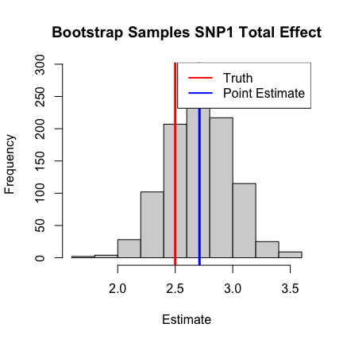

```r
hist(total_xx1,main="Bootstrap Samples SNP1 Total Effect",xlab="Estimate")
abline(v=eff[1,3],lwd=3,col='red')
abline(v=eff_est[1,3],lwd=3,col='blue')
legend("topright",c("Truth","Point Estimate"),col=c("red","blue"),lwd=2)
```

## 2.2 Logistic

Same as simulation 1 but with binomial link function connecting y with snps and gene sets.

```r
sim_params$family <- "binomial"
dat <- SimulateData(sim_params)
```

### 2.2.1 Model Fitting

```r
fit <- ComputePath(dat, mmn = T)
```

Given the simulation setting, we can approximate the true effects by approximating integral with large sample size by setting `n` to million observations.

```r
sim_params2 <- sim_params
sim_params2$n <- 1e6
dat2 <- SimulateData(sim_params2)
direct_t <- ComputeEffectxx(dat2,sim_params,"direct")
indirect_t <- ComputeEffectxx(dat2,sim_params,"indirect")
total_t <- ComputeEffectxx(dat2,sim_params,"total")
```

`ComputeEffectxx` provides estimation of direct, indirect and total effect.

```r
direct <- ComputeEffectxx(dat,fit,"direct")
indirect <- ComputeEffectxx(dat,fit,"indirect")
total <- ComputeEffectxx(dat,fit,"total")
eff_comb <- cbind(direct,direct_t,indirect,indirect_t,total,total_t)
rownames(eff_comb) <- names(fit$xx_direct)
colnames(eff_comb) <- c("est","true","est","true","est","true")
xx1total_sample <- eff_comb[1,5]
xx1total_true <- eff_comb[1,6]
```

Table below summarizes the Indirect, Direct, and Total effects.

```r
kable(eff_comb,digits=2) %>%
  kable_styling(bootstrap_options = "striped", full_width = F) %>%
  add_header_above(c(" ", "direct" = 2, "indirect" = 2, "total" = 2))
```

[output not shown]

### 2.2.2 Bootstrap

```r
B <- 1000
total_xx1 <- rep(0,length=B)
for(ii in 1:B){
  ix <- sample(1:sim_params$n,replace=TRUE)
  dat_boot <- mediateR:::SubsetDat(dat,ix)
  fit_boot <- ComputePath(dat_boot, mmn = T)
  total_xx1[ii] <- ComputeEffectxx(dat_boot,fit_boot,"total")[1]
}
L95 = round(quantile(total_xx1, 0.025),2)
U95 = round(quantile(total_xx1, 1 - 0.025),2)
```

Figure below shows the histgram of total effects of Bootstrap samples for SNP1. The 95% CI of the total effect for SNP1 is (1.32, 2.69)

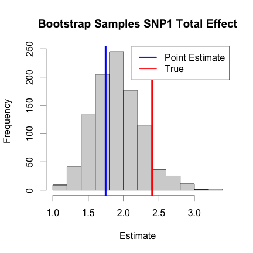

```r
hist(total_xx1,main="Bootstrap Samples SNP1 Total Effect",xlab="Estimate")
abline(v=xx1total_sample,lwd=3,col='blue')
abline(v=xx1total_true,lwd=3,col='red')
legend("topright",c("Point Estimate","True"),col=c("blue","red"),lwd=2)
```

## 2.3 Survival

Same as simulation 1 and 3 but with exponentially distributed survival times. The rate is $e^{\beta^Tx}$ where $x$ are the covariates. This model can be fit with Cox Proportional Hazards.

```r
sim_params$family <- "cox"
dat <- SimulateData(sim_params)
rmean <- max(as.matrix(dat$y)[,1])
```

### 2.3.1 Model Fitting

Same as simulation 1 and 3 but with exponentially distributed survival times. The rate is $e^{\beta^Tx}$ where $x$ are the covariates. This model can be fit with Cox Proportional Hazards. We compute the effects on mean survival restricted to 189.

```r
fit <- ComputePath(dat, mmn = T)
```

Given the simulation setting, we approximate true effects by approximating integral with large sample size use the maximum observed time as the restricted mean time.

```r
sim_params2 <- sim_params
sim_params2$n <- 1e4 # use many observations to approximate effects
dat2 <- SimulateData(sim_params2)
fit2 <- ComputePath(dat2, mmn = T)

direct_t <- ComputeEffectxx(dat2,fit2,"direct",rmean=rmean)
indirect_t <- ComputeEffectxx(dat2,fit2,"indirect",rmean=rmean)
total_t <- ComputeEffectxx(dat2,fit2,"total",rmean=rmean)
```

Similarly, `ComputeEffectxx` provides estimation of direct, indirect and total effect. `rmean`, the mean survival restricted to 189, needs to be provided to calculate the effect.

```r
direct <- ComputeEffectxx(dat,fit,"direct",rmean=rmean)
indirect <- ComputeEffectxx(dat,fit,"indirect",rmean=rmean)
total <- ComputeEffectxx(dat,fit,"total",rmean=rmean)
eff_comb <- cbind(direct,direct_t,indirect,indirect_t,total,total_t)
rownames(eff_comb) <- names(fit$xx_direct)
colnames(eff_comb) <- c("est","true","est","true","est","true")
xx1total_sample <- eff_comb[1,5]
xx1total_true <- eff_comb[1,6]
```

Table below summarizes the Indirect, Direct, and Total effects.

```r
kable(eff_comb,digits=2) %>%
  kable_styling(bootstrap_options = "striped", full_width = F) %>%
  add_header_above(c(" ", "direct" = 2, "indirect" = 2, "total" = 2))
```

|  | direct est | direct true | indirect est | indirect true | total est | total true |
| --- | --- | --- | --- | --- | --- | --- |
| x1 | -17.16 | -13.01 | -23.09 | -21.50 | -39.32 | -36.47 |
| x2 | -16.83 | -15.16 | 2.80 | 1.51 | -25.68 | -14.20 |
| x3 | -7.11 | -13.92 | -23.20 | -20.90 | -41.12 | -37.38 |

### 2.3.2 Bootstrap

```r
B <- 1000
total_xx1 <- rep(0,length=B)
for(ii in 1:B){
  ix <- sample(1:sim_params$n,replace=TRUE)
  dat_boot <- mediateR:::SubsetDat(dat,ix)
  fit_boot <- ComputePath(dat_boot, mmn = T)
  total_xx1[ii] <- ComputeEffectxx(dat_boot,fit_boot,"total",rmean=rmean)[1]
}
L95 = round(quantile(total_xx1, 0.025),2)
U95 = round(quantile(total_xx1, 1 - 0.025),2)
```

Figure below shows the histgram of total effects of Bootstrap samples for SNP1. The 95% CI of the total effect for SNP1 is (-47.05, -22.6)

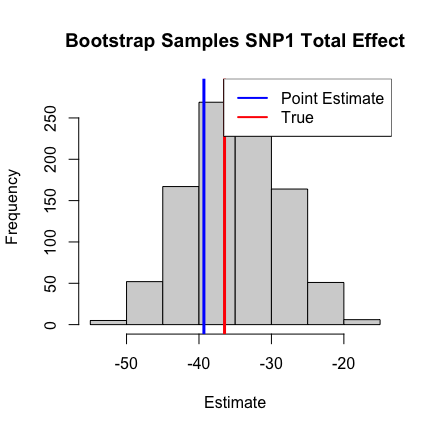

```r
hist(total_xx1,main="Bootstrap Samples SNP1 Total Effect",xlab="Estimate")
abline(v=xx1total_sample,lwd=3,col='blue')
abline(v=xx1total_true,lwd=3,col='red')
legend("topright",c("Point Estimate","True"),col=c("blue","red"),lwd=2)
```

### 2.3.3 Estimation of mediator-mediator relations.

Partial correlation between mediators adjusting for exposures and covariates

```r
sim_params <- mediateR:::QuickSim(n,4,5,"gaussian")
sim_params$family <- "cox"
dat <- SimulateData(sim_params)

dat <- SimulateData(sim_params)
rmean <- max(as.matrix(dat$y)[,1])

fit <- ComputePath(dat, mmn = T)
par1 = cov2cor(fit$cov_mm)
colnames(par1) = rownames(par1) = names(fit$mm_direct)
kable(par1,digits=2) %>%
  kable_styling(bootstrap_options = "striped", full_width = F)
```

|  | m1 | m2 | m3 | m4 | m5 |
| --- | --- | --- | --- | --- | --- |
| m1 | 1.00 | 0.03 | 0.06 | 0.01 | 0.05 |
| m2 | 0.03 | 1.00 | 0.01 | 0.00 | 0.00 |
| m3 | 0.06 | 0.01 | 1.00 | 0.00 | 0.04 |
| m4 | 0.01 | 0.00 | 0.00 | 1.00 | -0.01 |
| m5 | 0.05 | 0.00 | 0.04 | -0.01 | 1.00 |

Partial correlation between mediators adjusting for other mediators, exposures and covariates

```r
par2 = fit$ivcor_mm
colnames(par2) = rownames(par2) = names(fit$mm_direct)
kable(par2,digits=2) %>%
  kable_styling(bootstrap_options = "striped", full_width = F)
```

[output not shown]

Here we show how to compute confidence intervals and hypothesis tests using bootstrap sampling quantiles.

```r
B <- 100
corrmm <- array(0,dim = c(B, ncol(dat$mm),ncol(dat$mm)))
for(ii in 1:B){
  ix <- sample(1:sim_params$n,replace=TRUE)
  dat_boot <- mediateR:::SubsetDat(dat,ix)
  fit_boot <- ComputePath(dat_boot, mmn = T)
  corrmm[ii,,] <- fit_boot$ivcor_mm
}

L95 = round(quantile(corrmm[,1,2], 0.025),2)
U95 = round(quantile(corrmm[,1,2], 1 - 0.025),2)
```

The 95% CI of partial correlation adjusting for other mediators, exposures and covariates between `m1` and `m2` is (-0.13, 0.04). 0 is included in this interval suggesting that the partial correlation between `m1` and `m2` is not significant.